# How many Pittsburghers cross the river to get to work?

Conor Tompkins

11/15/2019

This post focuses on how many rivers Pittsburghers cross to get to work. I use the U.S. Census Bureau LEHD Origin-Destination Employment Statistics (LODES) [dataset](https://lehd.ces.census.gov/data/) to draw lines between “home” census tracts and “work” census tracts, and then count how many “commuter lines” intersect with the 3 main rivers in Pittsburgh. This calculation is done in straight lines “as the crow flies”, not accounting for actual road routes.

## TLDR

A plurality of commuters don’t cross any rivers, and none cross three.

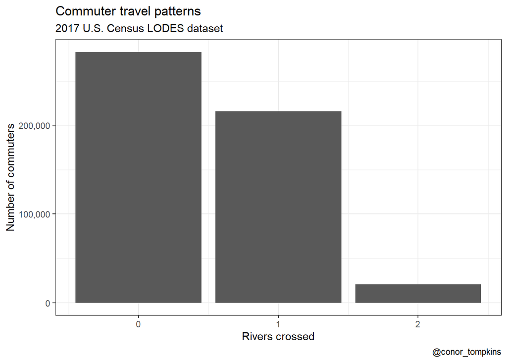

Many commuters in the Golden Triangle and neighborhoods to the east don’t cross rivers to get to work. Commuters from the North and South Hills areas usually cross one river. Commuters from Sewickley, Coraopolis, and those that live close to the airport are most likely to cross two rivers.

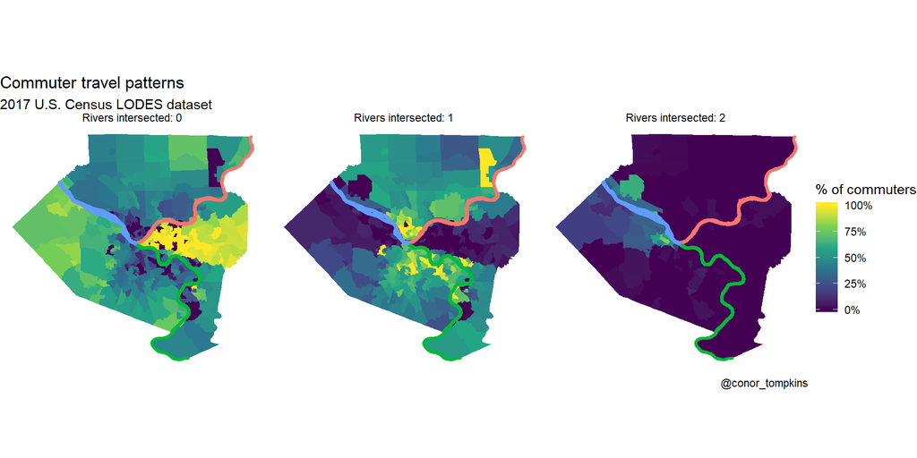

## Data munging and analysis

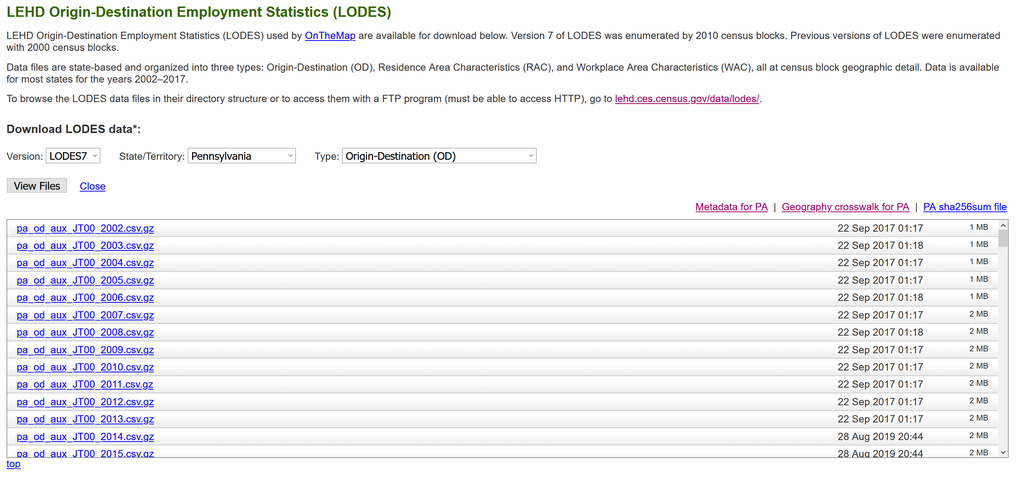

In my analysis I use many of the standard `{tidyverse}` packages, `{sf}`, `{tidycensus}`, `{tidygraph}`, and `{ggraph}`:

```r
library(tidyverse)
library(vroom)
library(sf)
library(tigris)
library(tidycensus)
library(tidygraph)
library(ggraph)
```

The first step is to read in the geographies crosswalk:

```r
geo_crosswalk <- vroom("data/pa_xwalk.csv.gz", col_types = cols(.default = "c"))

geo_crosswalk
```

```
## # A tibble: 421,545 x 43
##    tabblk2010 st    stusps stname cty   ctyname trct  trctname bgrp  bgrpname
##    <chr>      <chr> <chr>  <chr>  <chr> <chr>   <chr> <chr>    <chr> <chr>
##  1 420010301~ 42    PA     Penns~ 42001 Adams ~ 4200~ 301.01 ~ 4200~ 1 (Trac~
##  2 420010301~ 42    PA     Penns~ 42001 Adams ~ 4200~ 301.01 ~ 4200~ 1 (Trac~
##  3 420010301~ 42    PA     Penns~ 42001 Adams ~ 4200~ 301.01 ~ 4200~ 1 (Trac~
##  4 420010301~ 42    PA     Penns~ 42001 Adams ~ 4200~ 301.01 ~ 4200~ 1 (Trac~
##  5 420010301~ 42    PA     Penns~ 42001 Adams ~ 4200~ 301.01 ~ 4200~ 1 (Trac~
##  6 420010301~ 42    PA     Penns~ 42001 Adams ~ 4200~ 301.01 ~ 4200~ 1 (Trac~
##  7 420010301~ 42    PA     Penns~ 42001 Adams ~ 4200~ 301.01 ~ 4200~ 1 (Trac~
##  8 420010301~ 42    PA     Penns~ 42001 Adams ~ 4200~ 301.01 ~ 4200~ 1 (Trac~
##  9 420010301~ 42    PA     Penns~ 42001 Adams ~ 4200~ 301.01 ~ 4200~ 1 (Trac~
## 10 420010301~ 42    PA     Penns~ 42001 Adams ~ 4200~ 301.01 ~ 4200~ 1 (Trac~
## # ... with 421,535 more rows, and 33 more variables: cbsa <chr>,
## #   cbsaname <chr>, zcta <chr>, zctaname <chr>, stplc <chr>, stplcname <chr>,
## #   ctycsub <chr>, ctycsubname <chr>, stcd115 <chr>, stcd115name <chr>,
## #   stsldl <chr>, stsldlname <chr>, stsldu <chr>, stslduname <chr>,
## #   stschool <chr>, stschoolname <chr>, stsecon <chr>, stseconname <chr>,
## #   trib <chr>, tribname <chr>, tsub <chr>, tsubname <chr>, stanrc <chr>,
## #   stanrcname <chr>, necta <chr>, nectaname <chr>, mil <chr>, milname <chr>,
## #   stwib <chr>, stwibname <chr>, blklatdd <chr>, blklondd <chr>,
## #   createdate <chr>
```

This downloads the census tract shapefiles:

```r
allegheny_tracts <- get_decennial(geography = "tract",
                           variables = c(total_pop = "P001001"),
                           state = "PA",
                           county = "Allegheny County",
                           geometry = TRUE,
                           output = "wide")

allegheny_tracts
```

```
## Simple feature collection with 402 features and 3 fields
## geometry type:  MULTIPOLYGON
## dimension:      XY
## bbox:           xmin: -80 ymin: 40 xmax: -80 ymax: 41
## epsg (SRID):    4269
## proj4string:    +proj=longlat +datum=NAD83 +no_defs
## # A tibble: 402 x 4
##    GEOID   NAME               total_pop                                 geometry
##    <chr>   <chr>                  <dbl>                       <MULTIPOLYGON [°]>
##  1 420030~ Census Tract 103,~      6600 (((-80 40, -80 40, -80 40, -80 40, -80 ~
##  2 420030~ Census Tract 201,~      3629 (((-80 40, -80 40, -80 40, -80 40, -80 ~
##  3 420030~ Census Tract 203,~       616 (((-80 40, -80 40, -80 40, -80 40, -80 ~
##  4 420030~ Census Tract 305,~      2256 (((-80 40, -80 40, -80 40, -80 40, -80 ~
##  5 420030~ Census Tract 402,~      2604 (((-80 40, -80 40, -80 40, -80 40, -80 ~
##  6 420030~ Census Tract 404,~      2488 (((-80 40, -80 40, -80 40, -80 40, -80 ~
##  7 420030~ Census Tract 405,~      3694 (((-80 40, -80 40, -80 40, -80 40, -80 ~
##  8 420030~ Census Tract 406,~      2392 (((-80 40, -80 40, -80 40, -80 40, -80 ~
##  9 420030~ Census Tract 409,~      2969 (((-80 40, -80 40, -80 40, -80 40, -80 ~
## 10 420030~ Census Tract 501,~      1707 (((-80 40, -80 40, -80 40, -80 40, -80 ~
## # ... with 392 more rows
```

This is the [shapefile](https://data.wprdc.org/dataset/allegheny-county-major-rivers) of the rivers:

```r
rivers <- st_read("data/Allegheny_County_Major_Rivers/Allegheny_County_Major_Rivers.shp") %>%
  group_by(NAME) %>%
  summarize() %>%
  filter(!is.na(NAME))
rivers
```

```
## Simple feature collection with 3 features and 1 field
## geometry type:  POLYGON
## dimension:      XY
## bbox:           xmin: -80 ymin: 40 xmax: -80 ymax: 41
## epsg (SRID):    4326
## proj4string:    +proj=longlat +datum=WGS84 +no_defs
## # A tibble: 3 x 2
##   NAME                                                                  geometry
## * <fct>                                                            <POLYGON [°]>
## 1 Allegheny Riv~ ((-80 40, -80 40, -80 40, -80 40, -80 40, -80 40, -80 40, -80 ~
## 2 Monongahela R~ ((-80 40, -80 40, -80 40, -80 40, -80 40, -80 40, -80 40, -80 ~
## 3 Ohio River     ((-80 40, -80 40, -80 40, -80 40, -80 40, -80 40, -80 40, -80 ~
```

These are the rivers:

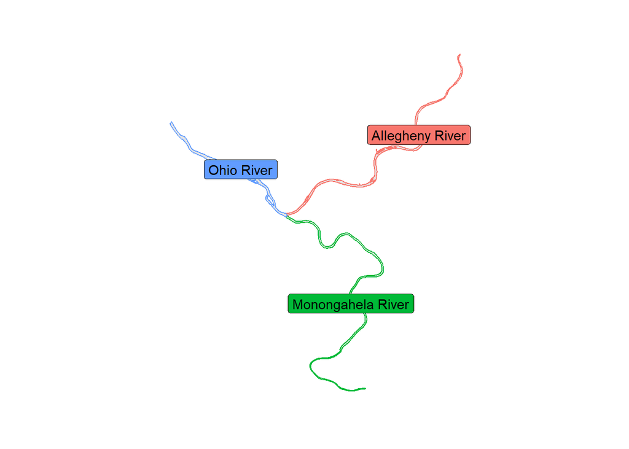

```r
rivers %>%
  ggplot() +
    geom_sf(aes(color = NAME), show.legend = FALSE) +
    geom_sf_label(aes(label = NAME, fill = NAME), show.legend = FALSE) +
    theme_graph()
```

This shows the outlines of the tracts used in the analysis.

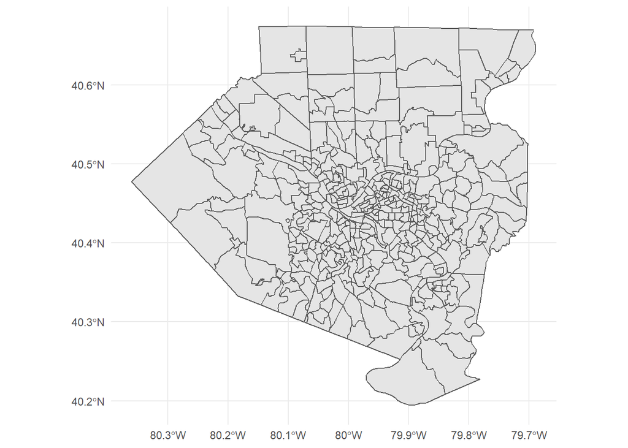

```r
allegheny_tracts %>%
  ggplot() +
    geom_sf() +
    theme_minimal()
```

Next I read in the main LODES data. This is a big file, so it takes a moment.

```r
df <- vroom("data/pa_od_main_JT00_2017.csv.gz", col_types = cols(.default = "c")) %>%
  mutate(S000 = as.numeric(S000)) %>%
  select(h_geocode, w_geocode, S000)

df
```

```
## # A tibble: 5,034,208 x 3
##    h_geocode       w_geocode        S000
##    <chr>           <chr>           <dbl>
##  1 420010301022005 420010301011003     1
##  2 420010303002001 420010301011003     1
##  3 420010301023038 420010301011012     1
##  4 420010314011078 420010301011012     1
##  5 420010301011027 420010301011016     1
##  6 420010301011033 420010301011016     1
##  7 420010301011038 420010301011016     1
##  8 420010301011116 420010301011016     1
##  9 420010301011123 420010301011016     1
## 10 420010302001018 420010301011016     1
## # ... with 5,034,198 more rows
```

Next I summarize the number of commuters per home-work tract combination. The original file uses census block codes, which are too granular for this analysis. I link the blocks to census tracts and aggregate to that level.

```r
df_tracts_summarized <- df %>%
  group_by(h_geocode, w_geocode) %>%
  summarize(commuters = sum(S000)) %>%
  ungroup() %>%
  arrange(desc(commuters))

df_tracts_summarized <- df_tracts_summarized %>%
  left_join(geo_crosswalk %>% select(tabblk2010, trct), by = c("h_geocode" = "tabblk2010")) %>%
  rename(h_tract = trct) %>%
  left_join(geo_crosswalk %>% select(tabblk2010, trct), by = c("w_geocode" = "tabblk2010")) %>%
  rename(w_tract = trct)

df_tracts_summarized <- df_tracts_summarized %>%
  group_by(h_tract, w_tract) %>%
  summarize(commuters = sum(commuters)) %>%
  ungroup() %>%
  arrange(desc(commuters))

df_tracts_summarized <- df_tracts_summarized %>%
  semi_join(allegheny_tracts, by = c("h_tract" = "GEOID")) %>%
  semi_join(allegheny_tracts, by = c("w_tract" = "GEOID"))
```

This code finds the center of each tract, which I use as the nodes in the network plots:

```r
allegheny_tracts <- allegheny_tracts %>%
  arrange(GEOID)

allegheny_tracts_centroids <- cbind(allegheny_tracts,
                                    st_coordinates(st_centroid(allegheny_tracts))) %>%
  st_set_geometry(NULL) %>%
  as_tibble() %>%
  rename(x = X,
         y = Y) %>%
  select(GEOID, x, y)
```

This shows that the centroids correctly appear in the center of each tract:

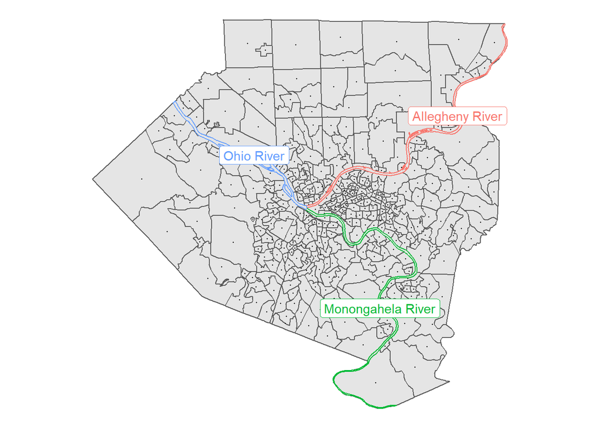

```r
allegheny_tracts %>%
  ggplot() +
    geom_sf() +
    geom_point(data = allegheny_tracts_centroids, aes(x, y), size = .2) +
    geom_sf(data = rivers, aes(color = NAME), show.legend = FALSE) +
    geom_sf_label(data = rivers, aes(color = NAME, label = NAME),
                  show.legend = FALSE) +
    theme_void()
```

```r
g <- df_tracts_summarized %>%
  as_tbl_graph(directed = TRUE) %>%
  activate(edges) %>%
  filter(commuters > 25)

g
```

```
## # A tbl_graph: 402 nodes and 2978 edges
## #
## # A directed multigraph with 17 components
## #
## # Edge Data: 2,978 x 3 (active)
##    from    to commuters
##   <int> <int>     <dbl>
## 1     1     1       721
## 2     2     1       619
## 3     2     2       488
## 4     3     1       487
## 5     4     1       442
## 6     5     5       442
## # ... with 2,972 more rows
## #
## # Node Data: 402 x 1
##   name
##   <chr>
## 1 42003020100
## 2 42003409000
## 3 42003191800
## # ... with 399 more rows
```

Here I set a manual layout for the `ggraph` object. I use the centroids of the census tracts as the nodes in the network graph.

```r
node_pos <- allegheny_tracts_centroids

manual_layout <- create_layout(graph = g,
                               layout = node_pos)

manual_layout %>%
  as_tibble()
```

```
## # A tibble: 402 x 7
##    GEOID           x     y name        .ggraph.orig_index .ggraph.index circular
##    <chr>       <dbl> <dbl> <chr>                    <int>         <int> <lgl>
##  1 42003010300 -80.0  40.4 42003020100                  1             1 FALSE
##  2 42003020100 -80.0  40.4 42003409000                  2             2 FALSE
##  3 42003020300 -80.0  40.5 42003191800                  3             3 FALSE
##  4 42003030500 -80.0  40.4 42003412001                  4             4 FALSE
##  5 42003040200 -80.0  40.4 42003452000                  5             5 FALSE
##  6 42003040400 -79.9  40.4 42003411000                  6             6 FALSE
##  7 42003040500 -80.0  40.4 42003456003                  7             7 FALSE
##  8 42003040600 -80.0  40.4 42003191700                  8             8 FALSE
##  9 42003040900 -80.0  40.4 42003413100                  9             9 FALSE
## 10 42003050100 -80.0  40.4 42003426300                 10            10 FALSE
## # ... with 392 more rows
```

This graphs the commuter lines on top of the census tracts and rivers:

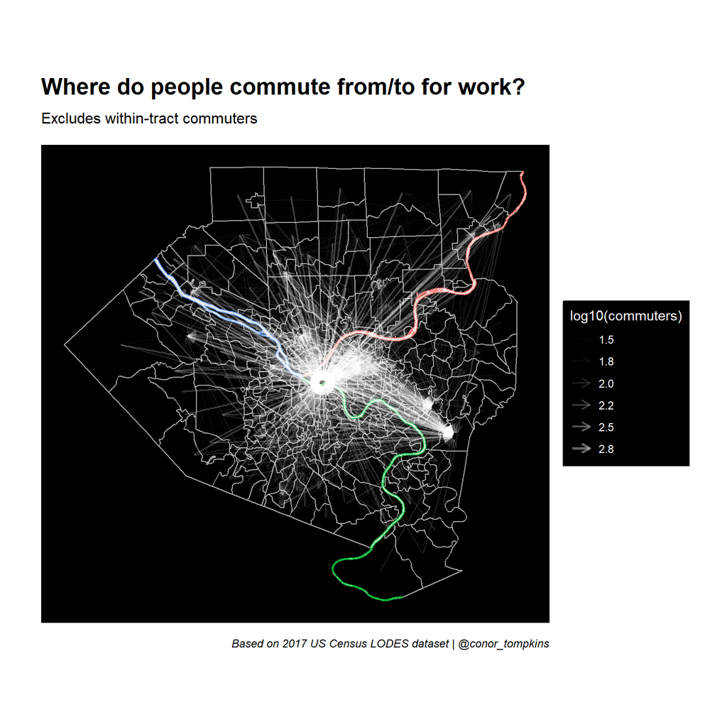

```r
ggraph(manual_layout) +
  geom_sf(data = allegheny_tracts, color = "dark grey", fill = NA) +
  geom_sf(data = rivers, aes(color = NAME), show.legend = FALSE) +
  geom_edge_fan(aes(edge_width = log10(commuters),
                    edge_alpha = log10(commuters)),
                arrow = arrow(length = unit(.5, 'lines')),
                start_cap = circle(.1, 'lines'),
                end_cap = circle(.2, 'lines'),
                color = "white",
                strength = .5) +
  scale_edge_width_continuous(range = c(.1, 1)) +
  scale_edge_alpha_continuous(range = c(.01, .4)) +
  labs(x = NULL,
       y = NULL,
       title = "Where do people commute from/to for work?",
       subtitle = "Excludes within-tract commuters",
       caption = "Based on 2017 US Census LODES dataset | @conor_tompkins") +
  theme_graph() +
  theme(legend.background = element_rect(fill = "black"),
        legend.text = element_text(color = "white"),
        legend.title = element_text(color = "white"),
        panel.background = element_rect(fill = "black"))
```

This calculates the centroids I will use to draw lines later on:

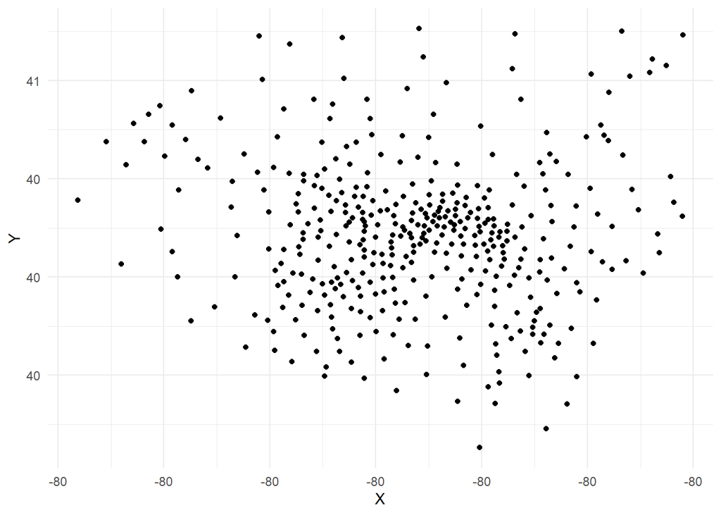

```r
allegheny_lines <- cbind(allegheny_tracts, st_coordinates(st_centroid(allegheny_tracts))) %>%
  select(-c(NAME, total_pop)) %>%
  st_drop_geometry()

allegheny_lines %>%
  ggplot() +
    geom_point(aes(X, Y)) +
    theme_minimal()
```

Here I calculate the edges and nodes for the network graph:

```r
df_edges <- g %>%
  activate(edges) %>%
  as_tibble()

df_nodes <- g %>%
  activate(nodes) %>%
  as_tibble() %>%
  mutate(id = row_number())
```

The `df_lines` is pivoted long so there is a “to” and “from” row for each commuter line:

```r
df_lines <- df_edges %>%
  mutate(line_id = row_number()) %>%
  pivot_longer(c(from, to), names_to = "point_type", values_to = "edge_id")

df_lines
```

```
## # A tibble: 5,956 x 4
##    commuters line_id point_type edge_id
##        <dbl>   <int> <chr>        <int>
##  1       721       1 from             1
##  2       721       1 to               1
##  3       619       2 from             2
##  4       619       2 to               1
##  5       488       3 from             2
##  6       488       3 to               2
##  7       487       4 from             3
##  8       487       4 to               1
##  9       442       5 from             4
## 10       442       5 to               1
## # ... with 5,946 more rows
```

Since some commuter “lines” are really just points that start and end at the same centroid, I separate the commuter “lines” from the “points” for purposes of manipulating the geometries.

```r
df_line_types <- df_lines %>%
  pivot_wider(names_from = point_type, values_from = edge_id) %>%
  mutate(line_type = case_when(from == to ~ "point",
                               from != to ~ "linestring")) %>%
  pivot_longer(cols = c(from, to), names_to = "edge_type", values_to = "edge_id")

df_line_types
```

```
## # A tibble: 5,956 x 5
##    commuters line_id line_type  edge_type edge_id
##        <dbl>   <int> <chr>      <chr>       <int>
##  1       721       1 point      from            1
##  2       721       1 point      to              1
##  3       619       2 linestring from            2
##  4       619       2 linestring to              1
##  5       488       3 point      from            2
##  6       488       3 point      to              2
##  7       487       4 linestring from            3
##  8       487       4 linestring to              1
##  9       442       5 linestring from            4
## 10       442       5 linestring to              1
## # ... with 5,946 more rows
```

```r
df_linestrings <- df_line_types %>%
  filter(line_type == "linestring")

df_points <- df_line_types %>%
  filter(line_type == "point")
```

This creates the geometries for the lines, points, and rivers. Then I set them all to the same coordinate system with `st_set_crs`.

```r
df_linestrings <- df_linestrings %>%
  left_join(df_nodes, by = c("edge_id" = "id")) %>%
  left_join(allegheny_lines, by = c("name" = "GEOID")) %>%
  st_as_sf(coords = c("X", "Y")) %>%
  group_by(line_id, commuters) %>%
  summarise() %>% # union points into lines using our created lineid
  st_cast("LINESTRING") %>%
  st_set_crs(4326)

df_points <- df_points %>%
  left_join(df_nodes, by = c("edge_id" = "id")) %>%
  left_join(allegheny_lines, by = c("name" = "GEOID")) %>%
  st_as_sf(coords = c("X", "Y")) %>%
  group_by(line_id, commuters) %>%
  summarise() %>% # union points into lines using our created lineid
  st_cast("POINT") %>%
  st_set_crs(4326)
```

```r
rivers <- rivers %>%
  st_set_crs(4326)
```

Here I calculate which commuter lines intersect with which rivers using `st_intersects`:

```r
df_linestrings_intersect <- df_linestrings %>%
  ungroup() %>%
  mutate(intersects_ohio = st_intersects(., rivers %>%
                                            filter(NAME == "Ohio River")) %>% as.logical(),
         intersects_allegheny = st_intersects(., rivers %>%
                                                filter(NAME == "Allegheny River")) %>% as.logical(),
         intersects_monongahela = st_intersects(., rivers %>%
                                                  filter(NAME == "Monongahela River")) %>% as.logical())

df_commuter_rivers <- df_linestrings_intersect %>%
  pivot_longer(c(contains("intersects")), names_to = "river_intersected", values_to = "value") %>%
  mutate(value = case_when(is.na(value) ~ FALSE,
                           !is.na(value) ~ value))
```

This shows that the intersection calculation was successful:

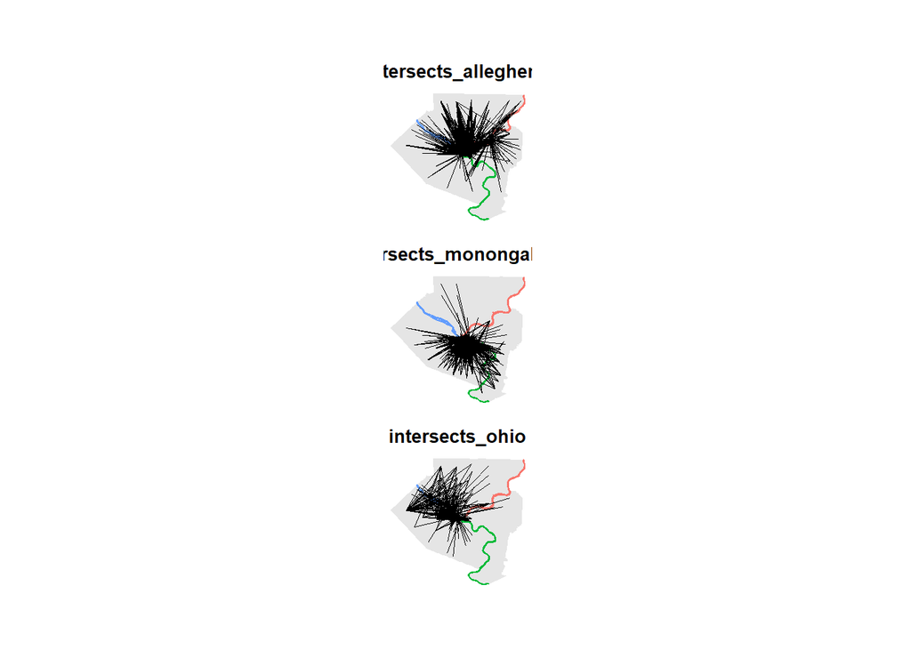

```r
df_commuter_rivers %>%
  filter(value == TRUE) %>%
  ggplot() +
    geom_sf(data = allegheny_tracts, color = NA, show.legend = FALSE) +
    geom_sf(data = rivers,
            aes(color = NAME),
            show.legend = FALSE) +
    geom_sf(aes(geometry = geometry,
                #color = value,
                size = commuters),
            #alpha = .1,
            show.legend = TRUE) +
    facet_wrap(~river_intersected,
               ncol = 1) +
    guides(color = FALSE,
           size = FALSE) +
    theme_graph() +
    scale_size_continuous(range = c(.1, .5))
```

This combines the dataframes with the lines and points, and then summarizes to count how many of the geometries intersected with a river:

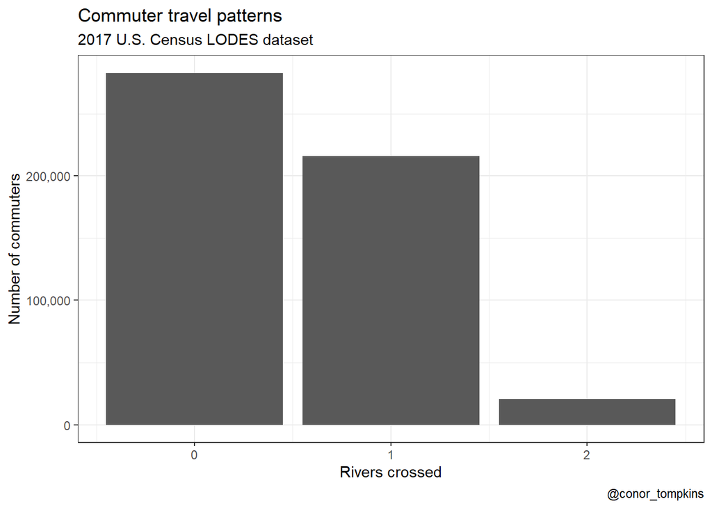

```r
df_commuter_rivers_summary <- df_commuter_rivers %>%
  bind_rows(df_points %>%
              mutate(value = FALSE)) %>%
  group_by(line_id) %>%
  summarize(rivers_crossed = sum(value),
            commuters = sum(commuters))

df_commuter_rivers_summary %>%
  group_by(rivers_crossed) %>%
  summarize(commuters = sum(commuters)) %>%
  ggplot(aes(rivers_crossed, commuters)) +
    geom_col() +
    scale_y_continuous(labels = scales::comma) +
    labs(title = "Commuter travel patterns",
         subtitle = "2017 U.S. Census LODES dataset",
         x = "Rivers crossed",
         y = "Number of commuters",
         caption = "@conor_tompkins") +
    theme_bw()
```

It is always reassuring when your analysis doesn’t stray to far from conventional wisdom. Very few Pittsburghers in the dataset cross two rivers to get to work, and none cross three.

## Mapping commuter patterns

The next step is to put this data on a map, since it is obviously spatial. The goal is to calculate the percentage of each census tract’s “from” commuters that crossed zero, one, two, and 3 rivers.

This prepares the edge data to be used to make a chloropleth map:

```r
df_lines_chloro <- df_edges %>%
  mutate(line_id = row_number()) %>%
  pivot_longer(c(from, to), names_to = "point_type", values_to = "edge_id")

df_lines_chloro
```

```
## # A tibble: 5,956 x 4
##    commuters line_id point_type edge_id
##        <dbl>   <int> <chr>        <int>
##  1       721       1 from             1
##  2       721       1 to               1
##  3       619       2 from             2
##  4       619       2 to               1
##  5       488       3 from             2
##  6       488       3 to               2
##  7       487       4 from             3
##  8       487       4 to               1
##  9       442       5 from             4
## 10       442       5 to               1
## # ... with 5,946 more rows
```

The next few steps are largely just coercing the geometry to do what I want it to do. Interested parties can read the code.

```r
df_line_types_chloro <- df_lines_chloro %>%
  #select(line_id, point_type, edge_id) %>%
  pivot_wider(names_from = point_type, values_from = edge_id) %>%
  mutate(line_type = case_when(from == to ~ "point",
                               from != to ~ "linestring")) %>%
  pivot_longer(cols = c(from, to), names_to = "edge_type", values_to = "edge_id")
```

```r
df_linestrings_chloro <- df_line_types_chloro %>%
  filter(line_type == "linestring")

df_linestrings_chloro_lookup <- df_linestrings_chloro %>%
  select(line_id, edge_type, edge_id) %>%
  pivot_wider(names_from = edge_type, values_from = edge_id)

df_points_chloro <- df_line_types %>%
  filter(line_type == "point")
```

```r
df_linestrings_chloro <- df_linestrings_chloro %>%
  left_join(df_nodes, by = c("edge_id" = "id")) %>%
  left_join(allegheny_lines, by = c("name" = "GEOID")) %>%
  st_as_sf(coords = c("X", "Y")) %>%
  group_by(line_id, commuters) %>%
  summarise() %>% # union points into lines using our created lineid
  st_cast("LINESTRING") %>%
  st_set_crs(4326) %>%
  left_join(df_linestrings_chloro_lookup, by = c("line_id" = "line_id")) %>%
  left_join(df_nodes, by = c("from" = "id")) %>%
  left_join(allegheny_lines, by = c("name" = "GEOID"))

df_points_chloro <- df_points_chloro %>%
  left_join(df_nodes, by = c("edge_id" = "id")) %>%
  left_join(allegheny_lines, by = c("name" = "GEOID")) %>%
  st_as_sf(coords = c("X", "Y")) %>%
  group_by(line_id, name, commuters) %>%
  summarise() %>% # union points into lines using our created lineid
  st_cast("POINT") %>%
  st_set_crs(4326)
```

```r
#rivers <- rivers %>%
#  st_set_crs(4326)
```

```r
df_linestrings_chloro_intersect <- df_linestrings_chloro %>%
  ungroup() %>%
  #left_join(df_lines_chloro_wide) %>%
  mutate(intersects_ohio = st_intersects(., rivers %>%
                                            filter(NAME == "Ohio River")) %>% as.logical(),
         intersects_allegheny = st_intersects(., rivers %>%
                                                filter(NAME == "Allegheny River")) %>% as.logical(),
         intersects_monongahela = st_intersects(., rivers %>%
                                                  filter(NAME == "Monongahela River")) %>% as.logical()) %>%
  st_set_geometry(NULL) %>%
  select(-c(from, to)) %>%
  rename(from = name)
```

```r
df_linestrings_chloro_intersect <- df_linestrings_chloro_intersect %>%
  mutate_at(vars(contains("intersect")), ~case_when(is.na(.) ~ FALSE,
                           !is.na(.) ~ .)) %>%
  mutate(no_intersect = case_when(intersects_allegheny == FALSE & intersects_monongahela == FALSE & intersects_ohio == FALSE ~ TRUE,
                                  TRUE ~ FALSE)) %>%
  select(line_id, from,
         #to,
         contains("intersect"), commuters) %>%
  pivot_longer(contains("intersect"), names_to = "river_intersected", values_to = "value")
```

```r
df_linestrings_chloro_intersect <- df_linestrings_chloro_intersect %>%
  mutate(commuters = case_when(value == FALSE ~ 0,
                               TRUE ~ commuters))
```

```r
df_linestrings_chloro_intersect <- df_linestrings_chloro_intersect %>%
  filter(value == TRUE) %>%
  group_by(line_id, from,
           #to,
           commuters) %>%
  summarize(count_rivers_intersected = sum(river_intersected != "no_intersect")) %>%
  ungroup()
```

```r
df_points_chloro <- cbind(df_points_chloro, st_coordinates(st_centroid(df_points_chloro))) %>%
  st_drop_geometry() %>%
  rename(from = name) %>%
  select(line_id, from, commuters) %>%
  mutate(count_rivers_intersected = 0)
```

```r
df_combined <- bind_rows(df_linestrings_chloro_intersect, df_points_chloro)
```

```r
df_combined <- df_combined %>%
  arrange(from, desc(count_rivers_intersected), desc(commuters))
```

These are the final steps to create the chloropleth:

```r
df_combined
```

```
## # A tibble: 2,978 x 4
##    line_id from        commuters count_rivers_intersected
##      <int> <chr>           <dbl>                    <dbl>
##  1     747 42003010300        63                        0
##  2    2194 42003020100        31                        2
##  3    1371 42003020100        42                        1
##  4    2290 42003020100        30                        1
##  5       1 42003020100       721                        0
##  6     630 42003020100        70                        0
##  7     730 42003020100        64                        0
##  8    1102 42003020100        49                        0
##  9    1629 42003020100        38                        0
## 10     349 42003020300       112                        0
## # ... with 2,968 more rows
```

This counts the number of commuters per “from” tract and “count of rivers intersected”. Note that there are multiple rows per “from” tract.

```r
df_chloro_map <- df_combined %>%
  ungroup() %>%
  group_by(from, count_rivers_intersected) %>%
  summarize(total_commuters = sum(commuters)) %>%
  ungroup()

df_chloro_map
```

```
## # A tibble: 722 x 3
##    from        count_rivers_intersected total_commuters
##    <chr>                          <dbl>           <dbl>
##  1 42003010300                        0              63
##  2 42003020100                        0             942
##  3 42003020100                        1              72
##  4 42003020100                        2              31
##  5 42003020300                        0             257
##  6 42003030500                        0             231
##  7 42003040200                        0             143
##  8 42003040400                        0             108
##  9 42003040500                        0              87
## 10 42003040600                        0              59
## # ... with 712 more rows
```

The next step is to calculate the percent of a “from” tract’s that crossed a given number of rivers:

```r
df_chloro_map <- df_chloro_map %>%
  group_by(from) %>%
  mutate(pct_of_commuters = total_commuters / sum(total_commuters)) %>%
  ungroup()

df_chloro_map
```

```
## # A tibble: 722 x 4
##    from        count_rivers_intersected total_commuters pct_of_commuters
##    <chr>                          <dbl>           <dbl>            <dbl>
##  1 42003010300                        0              63           1
##  2 42003020100                        0             942           0.901
##  3 42003020100                        1              72           0.0689
##  4 42003020100                        2              31           0.0297
##  5 42003020300                        0             257           1
##  6 42003030500                        0             231           1
##  7 42003040200                        0             143           1
##  8 42003040400                        0             108           1
##  9 42003040500                        0              87           1
## 10 42003040600                        0              59           1
## # ... with 712 more rows
```

Then I join `df_chloro_map` against the census tract geometry to get a complete list of all the tracts. I use `complete` to add rows for combinations of “from” tracts and `count_rivers_intersected` that did not appear in the data. Those added rows are given `0` for `pct_of_commuters` and `total_commuters`.

```r
df_chloro_map <- df_chloro_map %>%
  right_join(allegheny_tracts %>% select(GEOID) %>% st_set_geometry(NULL), by = c("from" = "GEOID")) %>%
  complete(from, count_rivers_intersected = c(0, 1, 2)) %>%
  filter(!is.na(count_rivers_intersected)) %>%
  replace_na(list(pct_of_commuters = 0, total_commuters = 0))

df_chloro_map
```

```
## # A tibble: 1,206 x 4
##    from        count_rivers_intersected total_commuters pct_of_commuters
##    <chr>                          <dbl>           <dbl>            <dbl>
##  1 42003010300                        0              63           1
##  2 42003010300                        1               0           0
##  3 42003010300                        2               0           0
##  4 42003020100                        0             942           0.901
##  5 42003020100                        1              72           0.0689
##  6 42003020100                        2              31           0.0297
##  7 42003020300                        0             257           1
##  8 42003020300                        1               0           0
##  9 42003020300                        2               0           0
## 10 42003030500                        0             231           1
## # ... with 1,196 more rows
```

The final step is to right join againt the census tract data to bring over the geometry.

```r
df_chloro_map <- df_chloro_map %>%
  right_join(allegheny_tracts, by = c("from" = "GEOID"))

glimpse(df_chloro_map)
```

```
## Observations: 1,206
## Variables: 7
## $ from                     <chr> "42003010300", "42003010300", "42003010300...
## $ count_rivers_intersected <dbl> 0, 1, 2, 0, 1, 2, 0, 1, 2, 0, 1, 2, 0, 1, ...
## $ total_commuters          <dbl> 63, 0, 0, 942, 72, 31, 257, 0, 0, 231, 0, ...
## $ pct_of_commuters         <dbl> 1.000, 0.000, 0.000, 0.901, 0.069, 0.030, ...
## $ NAME                     <chr> "Census Tract 103, Allegheny County, Penns...
## $ total_pop                <dbl> 6600, 6600, 6600, 3629, 3629, 3629, 616, 6...
## $ geometry                 <MULTIPOLYGON [°]> MULTIPOLYGON (((-80 40, -80.....
```

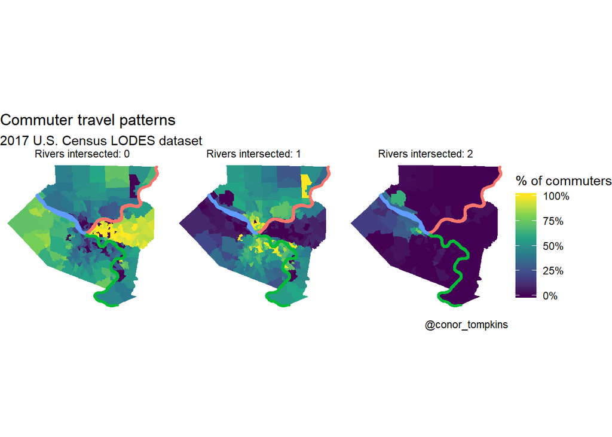

```r
df_chloro_map %>%
  mutate(count_rivers_intersected = str_c("Rivers intersected:", count_rivers_intersected, sep = " ")) %>%
  ggplot() +
    geom_sf(aes(geometry = geometry,
                fill = pct_of_commuters),
            color = NA) +
    geom_sf(data = rivers,
            aes(color = NAME),
            size = 1,
            show.legend = FALSE) +
    facet_wrap(~count_rivers_intersected,
               nrow = 1) +
    scale_fill_viridis_c("% of commuters",
                         labels = scales::percent) +
    labs(title = "Commuter travel patterns",
         subtitle = "2017 U.S. Census LODES dataset",
         caption = "@conor_tompkins") +
    theme_void()
```

### References

- https://lehd.ces.census.gov/data/
- https://lehd.ces.census.gov/data/lodes/LODES7/LODESTechDoc7.4.pdf
- https://lehd.ces.census.gov/doc/workshop/2017/Presentations/TheaEvans.pdf
- https://medium.com/@urban_institute/open-accessible-data-on-jobs-and-workers-tract-level-lodes-data-945fcac9e280